# AS4-1：簡單資料探索

Group0

2020-03-29 17:03:09

```r
# 載入基本的套件
pacman::p_load(dplyr,ggplot2)

# 載入、整理資料
load("twdemo.rdata")
demography %>% select(
   year=資料時間, city=縣市名稱, county=鄉鎮市區名稱, vill=村里名稱,
  pop=人口數,  marriage=結婚對數, college=大學院校人口數,  master=碩士人口數,phd=博士人口數,kid_yes = 非婚生已認領人數,kid_no=非婚生未認領人數
  ) -> D
D$year = gsub("Y","",D$year)  %>% as.integer
#D$female = as.integer(D$female)
table(D$year)
```

[output not shown]

# 結婚數和教育程度的關聯

## 結婚還有教育程度的差別

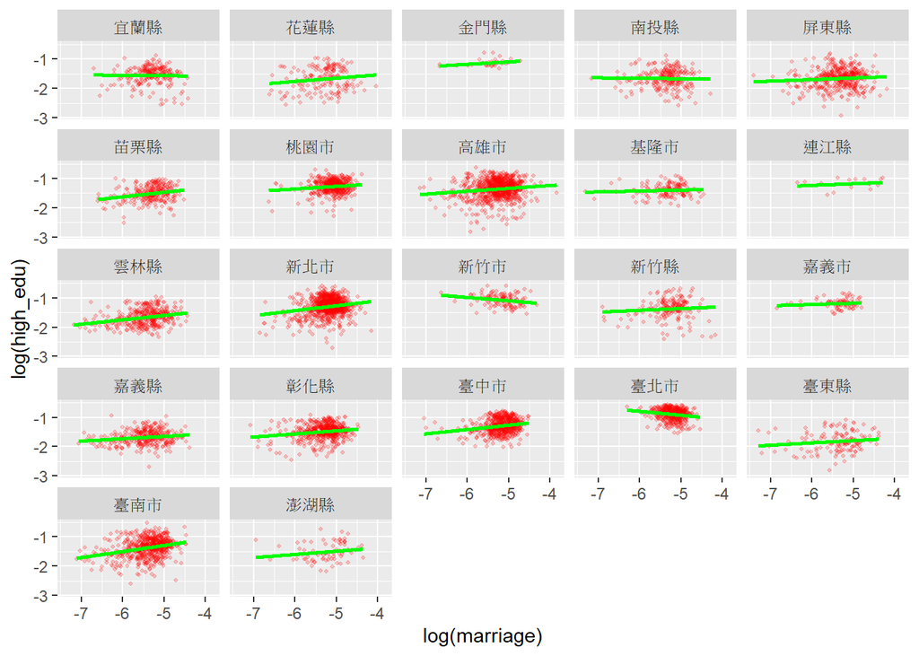

```r
D %>%
  filter(year == 107) %>% transmute(
  city,  marriage=marriage/pop, high_edu = (college+master+phd)/pop
  ) %>% ggplot(aes(x=log(marriage), y=log(high_edu))) +
  geom_point(size=0.8,alpha=0.2,col="red") +
  geom_smooth(method="lm",col="green",se=F) +
  facet_wrap(~city)
```

## 非婚生已認領子女數和教育程度的關聯

> 另外調查已認領非婚生子女數，發現全台大致呈現負向趨勢 但如台北市、台中市等較都市化、平均教育水平較高的縣市 負向的趨勢會較為減緩。而依據OECD的調查，已開發國家中 教育程度較高的地區，非婚生子女人數反而較高的現象有異曲同工之妙。

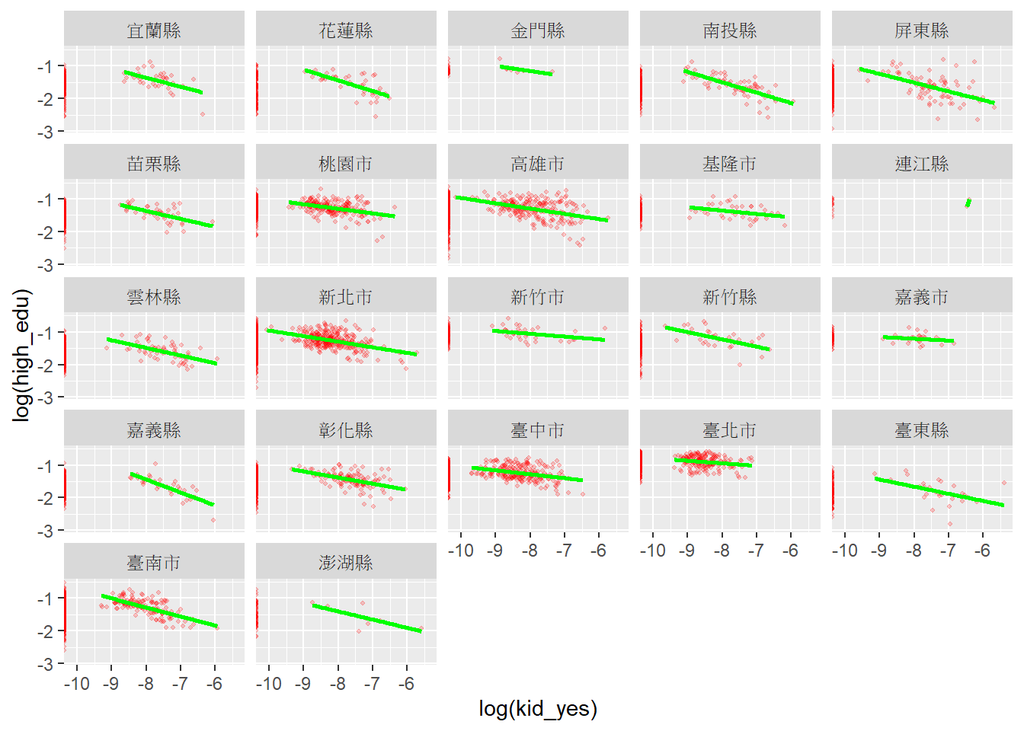

```r
D %>%
  filter(year == 107) %>% transmute(
  city,  kid_yes = kid_yes/pop, high_edu = (college+master+phd)/pop) %>% ggplot(aes(x=log(kid_yes), y=log(high_edu))) +
  geom_point(size=0.8,alpha=0.2,col="red") +
  geom_smooth(method="lm",col="green",se=F) +
  facet_wrap(~city)
```

# 結婚狀態各縣市比較

## 各縣市每年結婚對數變化

> 可以發現新北市、台北市、台中市、高雄市，結婚對數都位居全台前列 且在100年呈現高峰後，就逐年呈現下降趨勢

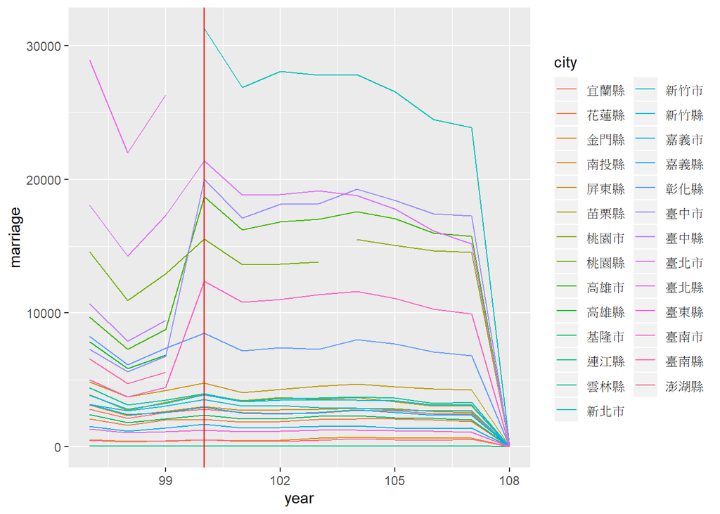

```r
D %>%
  group_by(city,year) %>%
  summarise(marriage = sum(marriage,na.rm = T)) %>%
  ggplot(aes(x=year, y=marriage, col=city)) + #pop是人口數
  geom_line() +
  geom_vline(xintercept=100 , col='red')
```

## 各縣市結婚比率的增長圖

> 為了避免偏差，我們將結婚對數除以當年度人口 得到各縣市當年的結婚率，發現100確實為結婚率最高的分水嶺 而後的幾年呈現持續震盪的趨勢，但以總比例來看 各縣市的結婚率其實相差不多

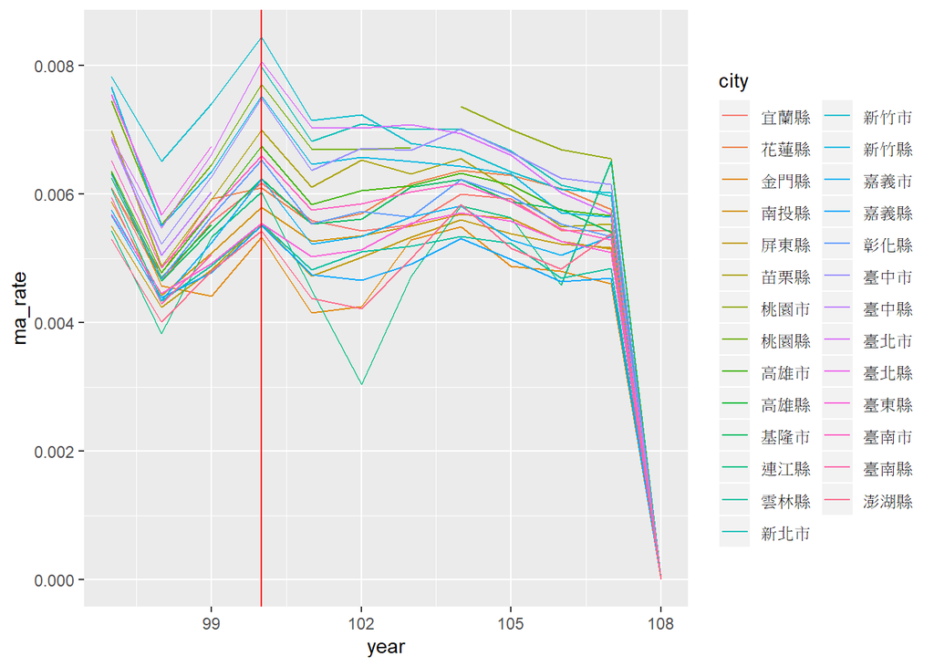

```r
D %>%
  group_by(city,year) %>%
  summarise(marriage = sum(marriage,na.rm = T),
            pop = sum(pop,na.rm = T)) %>%
  transmute(year,ma_rate = marriage/pop) %>%
  ggplot(aes(x=year, y=ma_rate, col=city)) + #pop是人口數
  geom_line() +
  geom_vline(xintercept=100 , col='red')
```

## 六都結婚人口總對數比較

> 發現結婚對數最高的是新北市216076對 接下來是台北市、台中市、高雄市、台南市、桃園市 可以發現除桃園市外，結婚數量較高的多為北部縣市 且有由北而南遞減的趨勢

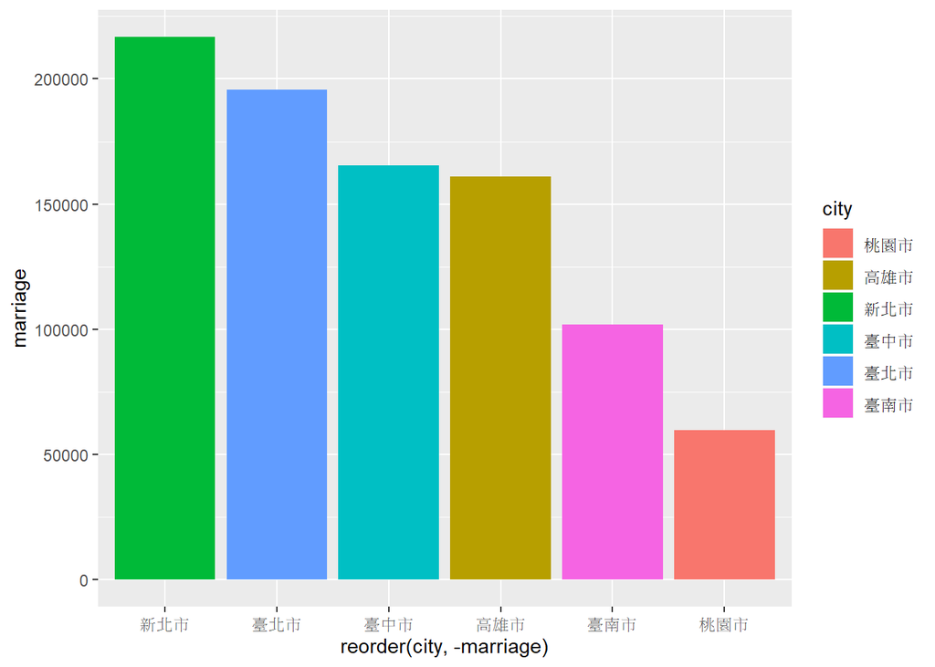

```r
city_5 = c('臺北市','新北市','桃園市','臺中市','臺南市','高雄市')

D %>%
  filter(city %in% city_5) %>%
  group_by(city) %>%
  summarise(marriage = sum(marriage,na.rm = T)) %>%
  arrange(desc(marriage)) %>%
  top_n(10) %>%
  ggplot(aes(x=reorder(city,-marriage),y=marriage , fill=city))+
  #reorder(想要排序欄位,依據排序欄位)
  geom_bar(stat = "identity")
```

## 各縣市每年的結婚人口增長圖

可發現各縣市結婚增長趨勢各都順序大多相同

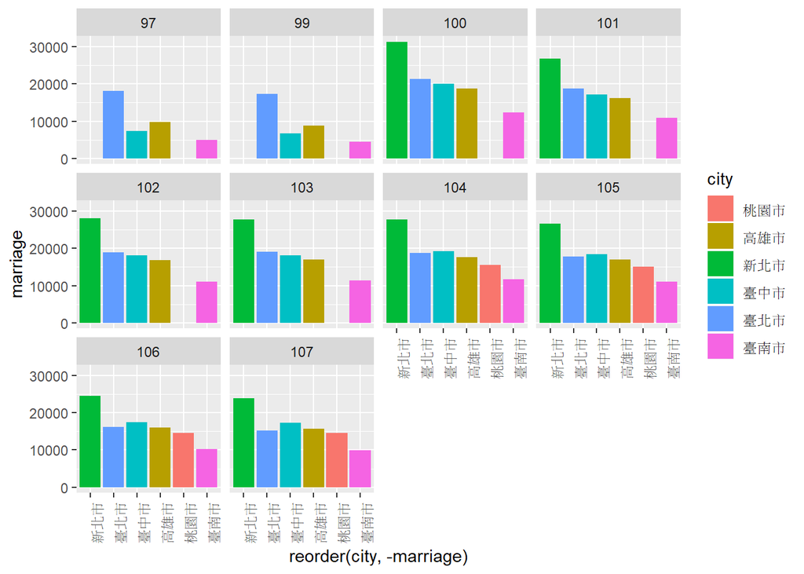

```r
D %>%
  filter(year < 108) %>%
  filter(city %in% city_5) %>%
  group_by(city,year) %>%
  summarise(marriage = sum(marriage,na.rm = T)) %>%
  arrange(desc(marriage)) %>%
  top_n(10) %>%
  ggplot(aes(x=reorder(city,-marriage),y=marriage , fill=city))+
  #reorder(想要排序欄位,依據排序欄位)
  geom_bar(stat = "identity")+
  facet_wrap(~year) +
  theme(axis.text.x = element_text(angle = 90)) #轉九十度
```